# Differential gene expression analysis on hematopoietic stem cells only

### Load of data and packages

```r
library("DESeq2")
library("tidyverse")
library("here")
library("ggprism")
library("patchwork")
library("ggrepel")
library("broom")


sample_data <- read_tsv(file = here("data/01_cleaned_sample_data.tsv"))
count_data <- read_rds(file = here("data/02_count_data_augments.Rdata"))
```

The aim of this analysis is to perform DGE analysis on samples that only contain HSC. We found a high variation in the gene expression between the different cell fractions in our first analysis. Now, we want to scope fully on HSC, as these are the biologically most important cells for MDS.

To generate a count matrix with normalized counts we have to apply the DESeq2 analysis on samples that only contain HSC. Hence, we need to filter out data that do not contain `cells == "HSC"`.

We get the sample ID (the one containing GSM….) from the samples that do not contain HSC.

```r
delete_cols <- sample_data |>
  filter(!cells == "HSC")

delete_cols <- delete_cols |>
  dplyr::select(sample)

delete_samples <- delete_cols$sample
```

And from the `count_data` we deselect these columns, so that we now only have HSC derived samples in the `count_data`.

```r
count_data <- count_data |>
  dplyr::select(-all_of(delete_samples))
```

We filter for samples that have HSC in the `cells`

```r
sample_data <- sample_data |>
  filter(cells == "HSC")
```

And convert `count_data` to numeric.

```r
count_data <- count_data |>
  mutate(across(everything(), as.numeric))
```

We then ensure, that the column variable `sample` in `sample_data` will be converted to rownames by the `column_to_rownames` function.

And in the next command we check that they are equal.

```r
sample_data <- sample_data |>
  column_to_rownames(var = "sample")

all(rownames(sample_data) == colnames(count_data))
```

```
## [1] TRUE
```

Then we run acquire the DESeq2 object from matrix

```r
dds_object_hsc_only <- DESeqDataSetFromMatrix(countData = count_data,
                                              colData = sample_data,
                                              design = ~ srsf2 + sf3b1 + diagnosis)
```

We estimate size factors

```r
dds_object_hsc_only <- estimateSizeFactors(object = dds_object_hsc_only)
```

And require normalized counts

```r
norm_counts <- counts(object = dds_object_hsc_only, normalize = TRUE)
```

Convert to data frame

```r
norm_counts <- data.frame(norm_counts)
```

Now we have the normalized counts for each sample.

We extract the rownames from the `norm_counts` and use them as values for the new variable `gene` and remove the rownames afterwards.

```r
gene_names <- base::rownames(x = norm_counts)

norm_counts <- norm_counts |>
  mutate(gene = gene_names)

base::rownames(norm_counts) <- NULL
```

Pivoting longer into a new column termed `sample` which contains the sample_id.

```r
counts_long <- norm_counts |>
  pivot_longer(cols = contains("GSM"),
               names_to = "sample",
               values_to = "counts") |>
  mutate(counts = round(x = counts, digits = 0))
```

And we join with sample_data on `sample`, where we firstly need to provide a variable `sample` in the `sample_data`.

```r
sample_id <- rownames(sample_data)

sample_data <- sample_data |>
  mutate(sample = sample_id)

base::rownames(sample_data) <- NULL
```

```r
full_data <- counts_long |>
  full_join(sample_data, by = "sample")
```

# PCA

To make the PCA we need to pivot the data into a wide format

```r
wide_count_data <- full_data |>
  pivot_wider(names_from = "gene", values_from = "counts")
```

And extract and scale the gene counts

```r
count_data_numeric <- wide_count_data |>
  dplyr::select(where(is.numeric))

count_data_to_keep <- colSums(x = count_data_numeric) > 10

count_data_numeric <- count_data_numeric[, count_data_to_keep]

count_data_scaled <- count_data_numeric |>
  scale()
```

Doing the PCA

```r
pca_object <- prcomp(x = count_data_scaled)
```

Using `augment` in `broom` to get the principal components

```r
augmented <- pca_object |>
  augment(wide_count_data)
```

And then we plot the first two principal components

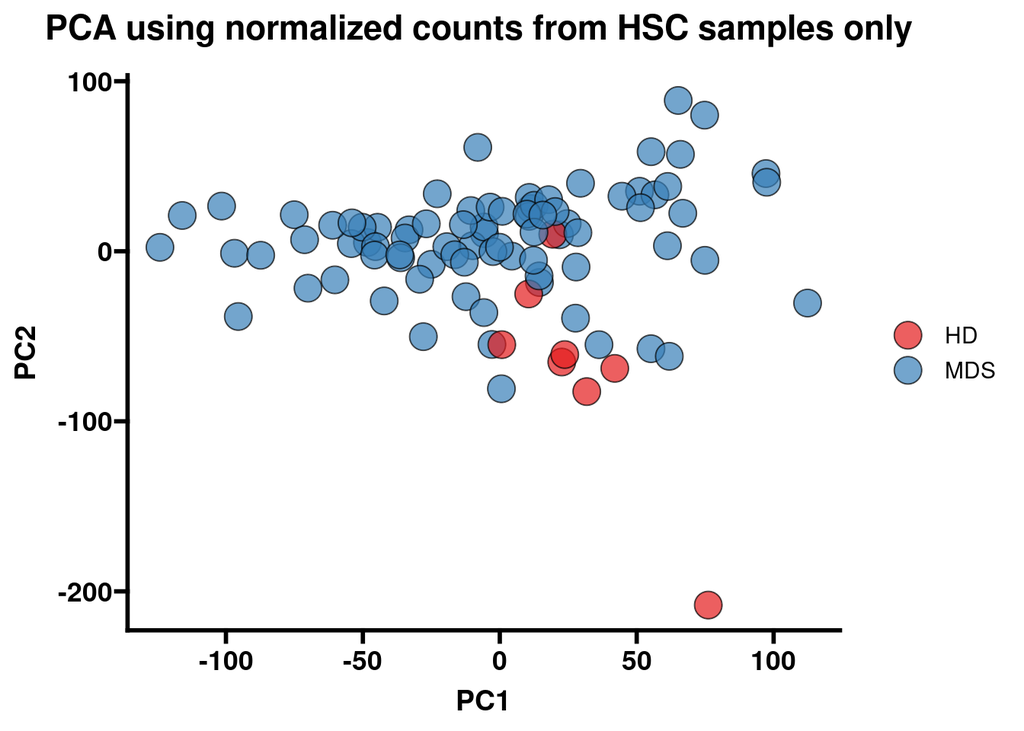

```r
pca_plot_hsc <- ggplot(data = augmented,
                       mapping = aes(x = .fittedPC1,
                                     y = .fittedPC2,
                                     fill = diagnosis)
) +
  geom_point(alpha = 0.7,
             size = 6,
             shape = 21,
             color = "black") +
  labs(title = "PCA using normalized counts from HSC samples only ",
       x = "PC1",
       y = "PC2",
       color = "Diagnosis") +
  theme_prism() +
  scale_fill_brewer(palette = "Set1")
pca_plot_hsc
```

As we have no evidence of clustering it is not worthwhile to make a scree plot.

# Differential gene expression analysis using data from the DESeq2 analysis.

We run the DESeq function on our deseq_object_hsc_only and then get the estimations using the `results` function.

```r
dds_object_hsc_only <- DESeq(dds_object_hsc_only)
```

```
## -- replacing outliers and refitting for 1787 genes
## -- DESeq argument 'minReplicatesForReplace' = 7
## -- original counts are preserved in counts(dds)
```

```r
results_hsc_only <- results(object = dds_object_hsc_only,
                            contrast = c("diagnosis", "MDS", "HD"),
                                         alpha = 0.05)
```

We convert the results into a dataframe, so that we can work with the coefficients.

```r
hsc_df <- data.frame(results_hsc_only)
```

And supply the rownames as the variable gene

```r
hsc_df <- hsc_df |>
  mutate(gene = rownames(hsc_df))
```

We use the data from this dataframe to establish a volcano plot where genes with a an adjusted p-value < 0.000001 have their names displayed.

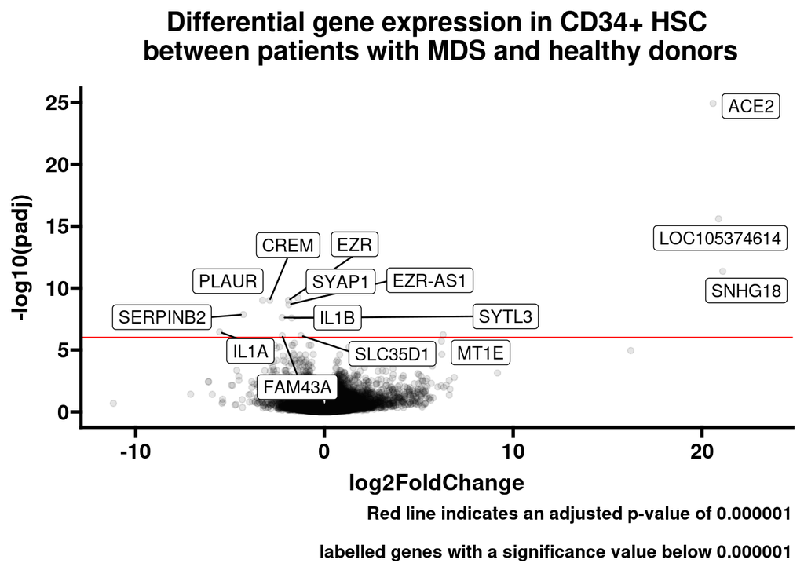

```r
ggplot(data = hsc_df,
       mapping = aes(x = log2FoldChange,
                     y = -log10(padj)
                     )
       ) +
  geom_hline(yintercept = -log10(0.000001),
             color = "red") +
  geom_point(alpha = 0.1) +
  geom_label_repel(data = hsc_df |>
                     filter(padj < 0.000001
                            ),
                   aes(label = gene),
                   max.overlaps = 20000,
                   nudge_x = 2) +
  theme_prism() +
  labs(title = "Differential gene expression in CD34+ HSC\n between patients with MDS and healthy donors",
       caption = "Red line indicates an adjusted p-value of 0.000001\n
       labelled genes with a significance value below 0.000001")
```

Looking at tumor microenvironment antigens

```r
tma <- c("CD274", "PDCD1LG2", "IDO1",   "TDO2", "ARG1", "ARG2", "TGFB1",    "CCL22",    "CCL2", "LGALS3", "LRRC32", "IL10", "SIGLEC15", "BIRC7")
```

Selecting only these genes from our dataframe

```r
df_tma <- hsc_df |>
  filter(gene %in% tma)
```

Showing how the expression of these genes is comparred to expression of other genes

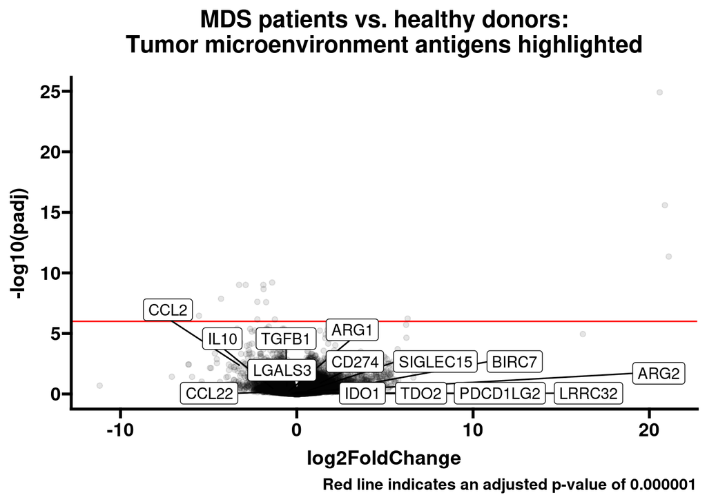

```r
ggplot(data = hsc_df,
       mapping = aes(x = log2FoldChange,
                     y = -log10(padj)
                     )
       ) +
  geom_hline(yintercept = -log10(0.000001),
             color = "red") +
  geom_point(alpha = 0.1) +
  geom_label_repel(data = df_tma, aes(label = gene),
                   max.overlaps = 10000,
                   nudge_x = 2) +
  theme_prism() +
  labs(title = "MDS patients vs. healthy donors:\nTumor microenvironment antigens highlighted",
       caption = "Red line indicates an adjusted p-value of 0.000001")
```

Making a volcano plot with the TMA encoding genes only

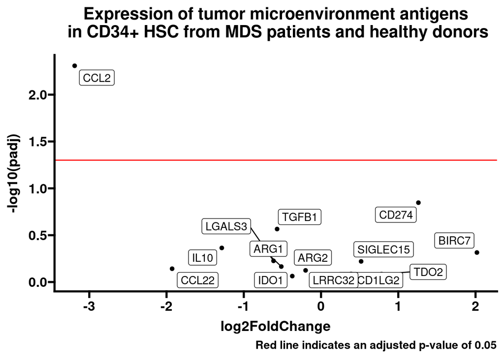

```r
ggplot(data = df_tma,
       mapping = aes(x = log2FoldChange,
                     y = -log10(padj)
                     )
       ) +
  geom_point() +
  geom_label_repel(aes(label = gene),
                   max.overlaps = 100) +
  geom_hline(yintercept = -log10(0.05),
             color = "red") +
  theme_prism() +
  labs(title = "Expression of tumor microenvironment antigens\n in CD34+ HSC from MDS patients and healthy donors",
       caption = "Red line indicates an adjusted p-value of 0.05")
```